# Exercise 06

Author

Gianfranco Botta (GianfrancoBotta)

Published

October 31, 2023

## Import libraries

```r
library(Rsubread)
library(knitr)
library(ggplot2)
library(corrplot)
library(pheatmap)
```

## Import data and obtain handy dataframes

```r
counts1 <- readRDS("countResult1.RDS")
counts2 <- readRDS("countResult2.RDS")

rsem_files_gene <- list.files(path = "RSEM_counts/", pattern = ".genes.results$", full.names = TRUE)
rsem_files_iso <- list.files(path = "RSEM_counts/", pattern = ".isoforms.results$", full.names = TRUE)
ncols <- length(rsem_files_gene)
nrows <- nrow(counts1$counts)
rsem_counts_gene <- matrix(NA, nrows, ncols, dimnames = list(counts1$annotation$GeneID, 1:ncols))
rsem_counts_gene <- matrix(NA, nrows, ncols, dimnames = list(counts1$annotation$GeneID, 1:ncols))

for (i in 1:length(rsem_files_gene)){
  rsem <- read.table(rsem_files_gene[i], sep="\t", header=TRUE)
  names <- rsem$gene_id
  counts <- rsem$expected_count
  new_order <- match(counts1$annotation$GeneID, names)
  counts <- counts[new_order]
  col_name <- gsub(".*/([NT][0-9])\\..*","\\1", rsem_files_gene[i])
  colnames(rsem_counts_gene)[i] <- col_name
  rsem_counts_gene[ ,i] <- counts
}

for (i in 1:length(rsem_files_iso)){
  rsem <- read.table(rsem_files_iso[i], sep="\t", header=TRUE)
  names_iso <- rsem$transcript_id
  counts <- rsem$expected_count
  if (i == 1){
    rsem_counts_iso <- matrix(NA, length(names_iso), ncols, dimnames = list(names_iso, 1:ncols))
  }
  col_name <- gsub(".*/([NT][0-9])\\..*","\\1", rsem_files_iso[i])
  colnames(rsem_counts_iso)[i] <- col_name
  rsem_counts_iso[ ,i] <- counts
}

rsem_counts_gene <- as.data.frame(rsem_counts_gene)
rsem_counts_iso <- as.data.frame(rsem_counts_iso)
feature_counts1 <- data.frame(counts1$counts)
colnames(feature_counts1) <- gsub(".*\\.([NT][0-9])\\..*","\\1", colnames(counts1$counts))
feature_counts2 <- data.frame(counts2$counts)
colnames(feature_counts2) <- gsub(".*\\.([NT][0-9])\\..*","\\1", colnames(counts2$counts))
```

When you run featureCounts on a set of RNA-seq data, it tries to map each read to a feature (usually a gene) to quantify the expression levels of those features. counts1 and counts2 are the results of two different types of mapping modalities using the same samples (3 normal and 3 treated). In particular, we obtain further insights of the reads in the section stat. The Rsem dataframes are results of an Rsem run, which provide isoform and gene level counts.

## Question 1

*Depending on the featureCount mode, how many alignments are ignored during counting?*

Since countResult1 does not consider multi-mapping reads, while countResult2 does, we have for sure a different number of ignored alignments in the two files.

```r
# get rid of the assigned reads
ig_al1 <- counts1$stat[-1, ]
ig_al2 <- counts2$stat[-1, ]

kable(ig_al1)
```

|  | Status | STAR_mapped.N1.bam | STAR_mapped.N2.bam | STAR_mapped.N3.bam | STAR_mapped.T1.bam | STAR_mapped.T2.bam | STAR_mapped.T3.bam |
| --- | --- | --- | --- | --- | --- | --- | --- |
| 2 | Unassigned_Ambiguity | 0 | 0 | 0 | 0 | 0 | 0 |
| 3 | Unassigned_MultiMapping | 50267 | 54371 | 56208 | 97028 | 80619 | 80559 |
| 4 | Unassigned_NoFeatures | 133 | 135 | 115 | 142 | 120 | 133 |
| 5 | Unassigned_Unmapped | 0 | 0 | 0 | 0 | 0 | 0 |
| 6 | Unassigned_MappingQuality | 0 | 0 | 0 | 0 | 0 | 0 |
| 7 | Unassigned_FragmentLength | 0 | 0 | 0 | 0 | 0 | 0 |
| 8 | Unassigned_Chimera | 0 | 0 | 0 | 0 | 0 | 0 |
| 9 | Unassigned_Secondary | 0 | 0 | 0 | 0 | 0 | 0 |
| 10 | Unassigned_Nonjunction | 0 | 0 | 0 | 0 | 0 | 0 |
| 11 | Unassigned_Duplicate | 0 | 0 | 0 | 0 | 0 | 0 |

```r
kable(ig_al2)
```

|  | Status | STAR_mapped.N1.bam | STAR_mapped.N2.bam | STAR_mapped.N3.bam | STAR_mapped.T1.bam | STAR_mapped.T2.bam | STAR_mapped.T3.bam |
| --- | --- | --- | --- | --- | --- | --- | --- |
| 2 | Unassigned_Ambiguity | 0 | 0 | 0 | 0 | 0 | 0 |
| 3 | Unassigned_MultiMapping | 0 | 0 | 0 | 0 | 0 | 0 |
| 4 | Unassigned_NoFeatures | 3244 | 3723 | 3665 | 11070 | 6987 | 6830 |
| 5 | Unassigned_Unmapped | 0 | 0 | 0 | 0 | 0 | 0 |
| 6 | Unassigned_MappingQuality | 0 | 0 | 0 | 0 | 0 | 0 |
| 7 | Unassigned_FragmentLength | 0 | 0 | 0 | 0 | 0 | 0 |
| 8 | Unassigned_Chimera | 0 | 0 | 0 | 0 | 0 | 0 |
| 9 | Unassigned_Secondary | 0 | 0 | 0 | 0 | 0 | 0 |
| 10 | Unassigned_Nonjunction | 0 | 0 | 0 | 0 | 0 | 0 |
| 11 | Unassigned_Duplicate | 0 | 0 | 0 | 0 | 0 | 0 |

We can immediately notice that, as we expected, in the first case there are many more unassigned reads because multi-mapping reads are not considered. However, even if the total amount of unassigned reads is greater in the first mapping modality, we observe a significant increase in the Unassigned_NoFeatures in the second mapping modality. These unassigned reads include usually: reads from non-coding regions, low-quality reads, and unannotated features (if the feature annotation used by featureCounts is incomplete and does not cover all potential genomic elements). However, these unassigned reads are still valuable information because they indicate that there are sequences in the data that do not correspond to known features or may require further investigation. The main reason of this huge increase in the Unassigned_NoFeatures reads is that in the second case you do not ignore multi-mapping reads, hence if some of these multi-mapping reads map 5 times to the non-annotated part of the genome, those reads will be counted more time in the Unassigned_NoFeatures reads.

Now we can compute the exact number of ignored alignments in each sample in the two modalities and visualize all the unassigned reads in a histogram.

```r
ig_al1_sum <- colSums(ig_al1[,-1])
ig_al2_sum <- colSums(ig_al2[,-1])

ig1_df <- data.frame(Un_Alignments = ig_al1_sum,
                     Indices = 1:6)
ig2_df <- data.frame(Un_Alignments = ig_al2_sum,
                     Indices = 1:6)
kable(ig1_df)
```

|  | Un_Alignments | Indices |
| --- | --- | --- |
| STAR_mapped.N1.bam | 50400 | 1 |
| STAR_mapped.N2.bam | 54506 | 2 |
| STAR_mapped.N3.bam | 56323 | 3 |
| STAR_mapped.T1.bam | 97170 | 4 |
| STAR_mapped.T2.bam | 80739 | 5 |
| STAR_mapped.T3.bam | 80692 | 6 |

```r
kable(ig2_df)
```

|  | Un_Alignments | Indices |
| --- | --- | --- |
| STAR_mapped.N1.bam | 3244 | 1 |
| STAR_mapped.N2.bam | 3723 | 2 |
| STAR_mapped.N3.bam | 3665 | 3 |
| STAR_mapped.T1.bam | 11070 | 4 |
| STAR_mapped.T2.bam | 6987 | 5 |
| STAR_mapped.T3.bam | 6830 | 6 |

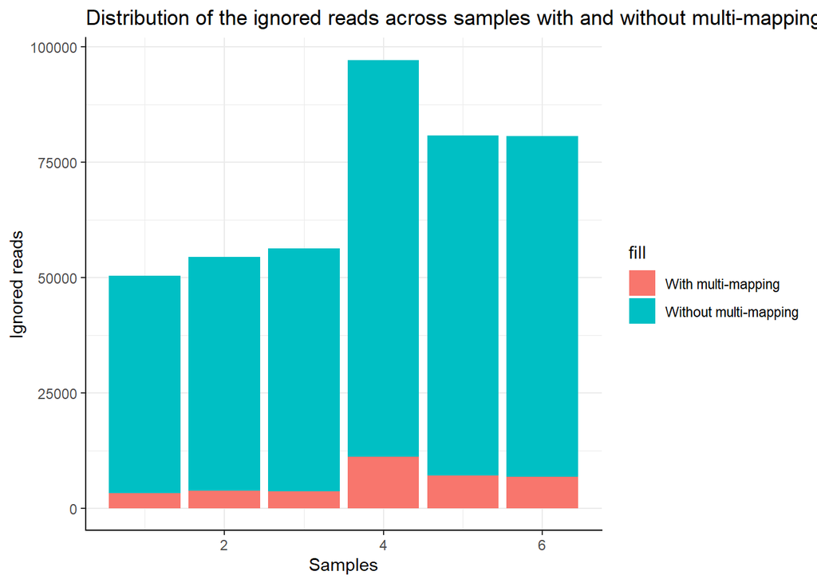

```r
p <- ggplot(data = ig1_df, aes(x = Indices, y = Un_Alignments, fill = "Without multi-mapping")) +
  geom_histogram(stat = "identity") +
  theme_bw() +
  theme(
    panel.border = element_blank(),
    axis.line = element_line(color = "black", linewidth = 0.5, lineend = "square")
  ) +
  labs(x = "Samples",
       y = "Ignored reads") +
ggtitle("Distribution of the ignored reads across samples with and without multi-mapping reads")
p + geom_histogram(data = ig2_df, aes(x = Indices, y = Un_Alignments, fill = "With multi-mapping"), stat = 'identity')
```

```r
p <- p + scale_fill_manual(values = c("Without multi-mapping", "With multi-mapping"), name = "Method")
```

We can see the great change depending on the featureCount mode you use. However if we want an exact number for the two modes we have to calculate them. Hence, the total number of ignored reads for each modality is therefore:

```r
ignored_1 <- sum(ig1_df$Un_Alignments)
ignored_2 <- sum(ig2_df$Un_Alignments)

print(ignored_1)
```

```
[1] 419830
```

```r
print(ignored_2)
```

```
[1] 35519
```

hence, we conclude that counting multi-mapping reads significantly reduce the number of ignored reads.

## Question 2

*Compare the counts from featureCounts with the genelevel counts from RSEM. Which genes have different values?*

To compare the counts we need the expected counts from the Rsem results. First, we start by creting a scatter plot of the two sets of data and visualize how much the counts differ between the two methods.

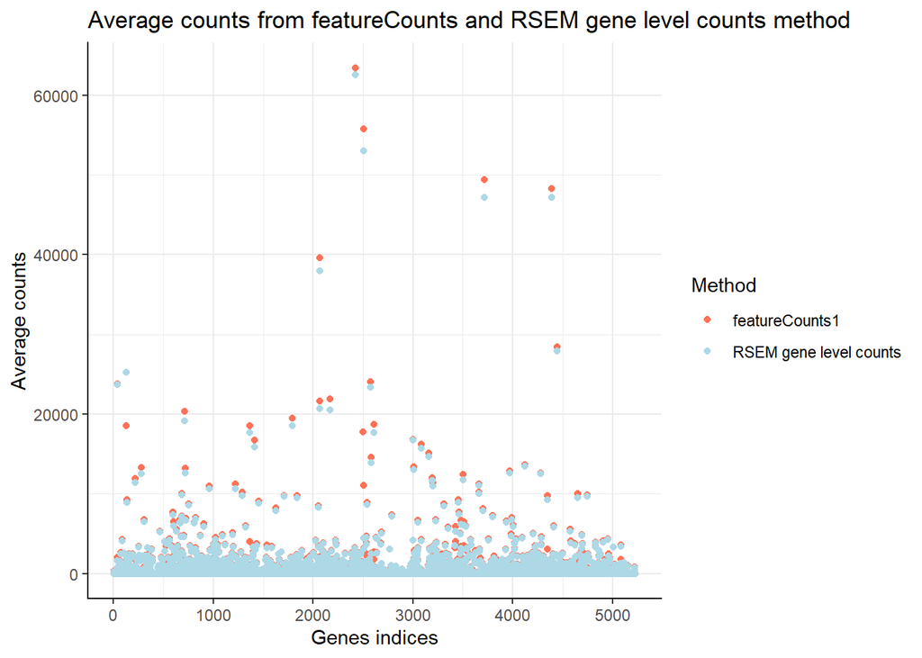

```r
# order the two dataframes to compare the counts
new_order <- match(rownames(rsem_counts_gene), rownames(feature_counts1))
feature_counts1 <- feature_counts1[new_order, ]

visualizing_fCounts <- data.frame(Counts = rowMeans(feature_counts1),
                              Indices = 1:nrow(feature_counts1))
visualizing_glCounts <- data.frame(Counts = rowMeans(rsem_counts_gene),
                              Indices = 1:nrow(feature_counts1))
combined_df <- rbind(visualizing_fCounts, visualizing_glCounts)
combined_df$Method <- factor(c(rep("featureCounts1", nrow(feature_counts1)), rep("RSEM gene level counts", nrow(feature_counts1))))


ggplot(combined_df, aes(x = Indices, y = Counts, color = Method)) +
  geom_point() +
  scale_color_manual(values = c("featureCounts1"="coral1", "RSEM gene level counts"="lightblue")) +
  theme_bw() +
  theme(
    panel.border = element_blank(),
    axis.line = element_line(color = "black", linewidth = 0.5, lineend = "square")
  ) +
  labs(x = "Genes indices", y = "Average counts") +
  ggtitle("Average counts from featureCounts and RSEM gene level counts method")
```

From this scatter plot we notice slightly different results between the two methods, in particular we observe a pattern in which the counts from featureCounts are slightly more than the expected counts of RSEM.

```r
diff_counted_genes1 <- which(rowMeans(feature_counts1-rsem_counts_gene) != 0)
length(diff_counted_genes1)
```

```
[1] 2565
```

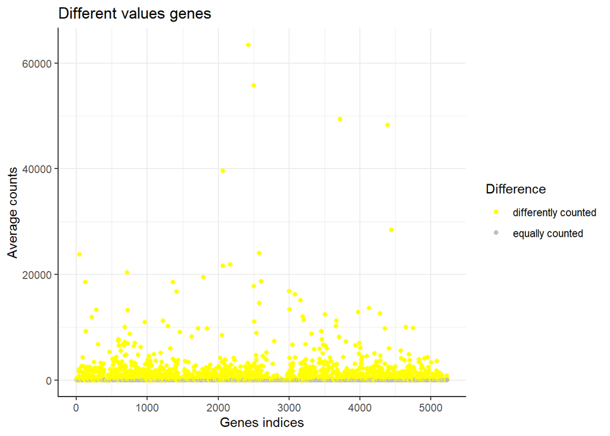

```r
combined_df$Difference <- rep("equally counted", 2*nrow(feature_counts1))
combined_df$Difference[diff_counted_genes1] <- "differently counted"
combined_df$Difference[2*diff_counted_genes1] <- "differently counted"

ggplot(combined_df[1:nrow(feature_counts1),], aes(x = Indices, y = Counts, color = Difference)) +
  geom_point() +
  scale_color_manual(values = c("differently counted"="yellow", "equally counted"="grey")) +
  theme_bw() +
  theme(
    panel.border = element_blank(),
    axis.line = element_line(color = "black", linewidth = 0.5, lineend = "square")
  ) +
  labs(x = "Genes indices", y = "Average counts") +
  ggtitle("Different values genes")
```

Once again, we see that there are a lot of differently counted genes, since we count as different genes even the ones with very small difference in the two methods.

Since we considered only the counts produced by featureCounts without multi-mapping reads, we can now apply the same process to the counts with multi-mapping reads:

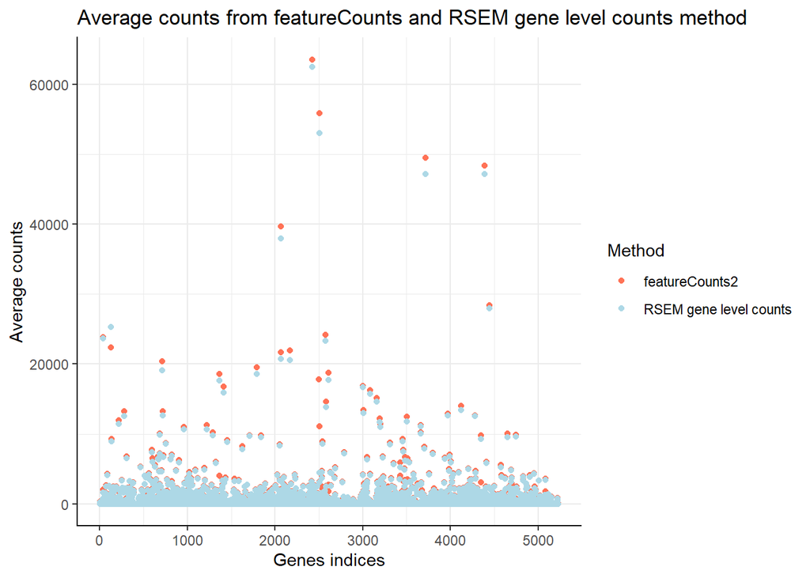

```r
# order the two dataframes to compare the counts
new_order <- match(rownames(rsem_counts_gene), rownames(feature_counts2))
feature_counts2 <- feature_counts2[new_order, ]

visualizing_fCounts <- data.frame(Counts = rowMeans(feature_counts2),
                              Indices = 1:nrow(feature_counts2))
visualizing_glCounts <- data.frame(Counts = rowMeans(rsem_counts_gene),
                              Indices = 1:nrow(feature_counts2))
combined_df <- rbind(visualizing_fCounts, visualizing_glCounts)
combined_df$Method <- factor(c(rep("featureCounts2", nrow(feature_counts2)), rep("RSEM gene level counts", nrow(feature_counts2))))


ggplot(combined_df, aes(x = Indices, y = Counts, color = Method)) +
  geom_point() +
  scale_color_manual(values = c("featureCounts2"="coral1", "RSEM gene level counts"="lightblue")) +
  theme_bw() +
  theme(
    panel.border = element_blank(),
    axis.line = element_line(color = "black", linewidth = 0.5, lineend = "square")
  ) +
  labs(x = "Genes indices", y = "Average counts") +
  ggtitle("Average counts from featureCounts and RSEM gene level counts method")
```

```r
diff_counted_genes2 <- which(rowMeans(feature_counts2-rsem_counts_gene) != 0)
length(diff_counted_genes2)
```

```
[1] 2835
```

We notice that out of 5228 genes, 2835 have different values in the two counting methods. If we want to provide a scatter plot of the differently counted genes even between these two sets of data:

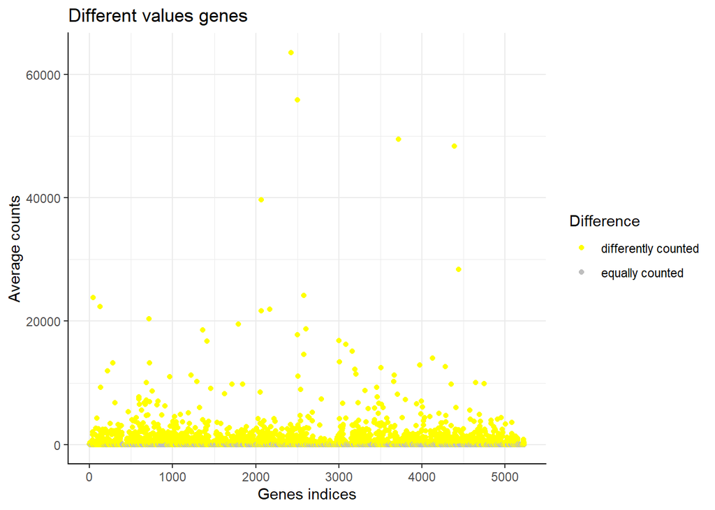

```r
combined_df$Difference <- rep("equally counted", 2*nrow(feature_counts2))
combined_df$Difference[diff_counted_genes2] <- "differently counted"
combined_df$Difference[2*diff_counted_genes2] <- "differently counted"

ggplot(combined_df[1:nrow(feature_counts2),], aes(x = Indices, y = Counts, color = Difference)) +
  geom_point() +
  scale_color_manual(values = c("differently counted"="yellow", "equally counted"="grey")) +
  theme_bw() +
  theme(
    panel.border = element_blank(),
    axis.line = element_line(color = "black", linewidth = 0.5, lineend = "square")
  ) +
  labs(x = "Genes indices", y = "Average counts") +
  ggtitle("Different values genes")
```

## Question 3

*How does the sum of the counts in RSEM compare to the number of the aligned reads?*

What we want to do is compare the number of reads computed by the aligner in RSEM with the number of expected reads using EM in RSEM model, so the gene level counts. ‘expected_count’ is the sum of the posterior probability of each read comes from a transcript over all reads.

```r
rsem_files_counts <- list.files(path = "RSEM_counts/", pattern = ".cnt$", full.names = TRUE, recursive = TRUE)

aligned_reads <- vector(mode = "numeric", length = length(rsem_files_counts))

for (i in 1:length(rsem_files_counts)){
  rsem_counts <- read.table(rsem_files_counts[i], sep="", header=FALSE, nrows = 1)
  aligned_reads[i] <- rsem_counts[ ,2]
}

comparison <- sum(rsem_counts_gene)/sum(aligned_reads)
comparison
```

```
[1] 0.9999845
```

Since the ratio between expected counts and aligned reads is very close to 1, we can conclude that the number of expected reads is very reliable in this case, which may be due to a great quality of the reads or a small background noise. This make sense, since the sum of expected counts for all transcripts are generally less than the total number of reads aligned, due to two main reasons: - each read aligning to this transcript has a probability of being generated from background noise, - RSEM may filter some alignable low quality reads.

We used the gene level counts but using the isoform level counts would have produced the same results, since the first ones are obtained from the sum of the second one for each gene.

## Question 4

*Compute pair-wise correlation of the samples based on the isoform counts and gene level counts.*

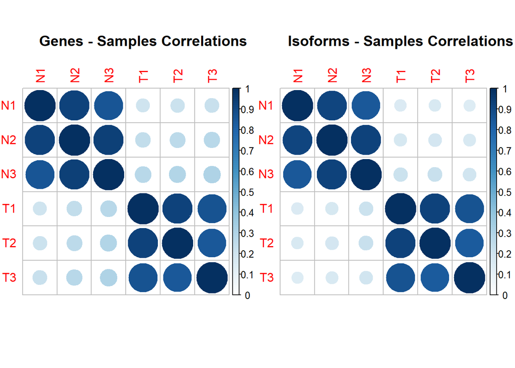

```r
cor_gene <- cor(rsem_counts_gene, use = "pairwise")
cor_iso <- cor(rsem_counts_iso, use = "pairwise")

par(mfrow=c(1,2))
corrplot(cor_gene, method = "circle", col.lim = c(0, 1), cl.pos="r")
title("Genes - Samples Correlations", line = 1)

corrplot(cor_iso, method = "circle", col.lim = c(0, 1), cl.pos="r")
title("Isoforms - Samples Correlations", line = 1)
```

To visualize the correlation in another way, we can use heatmaps:

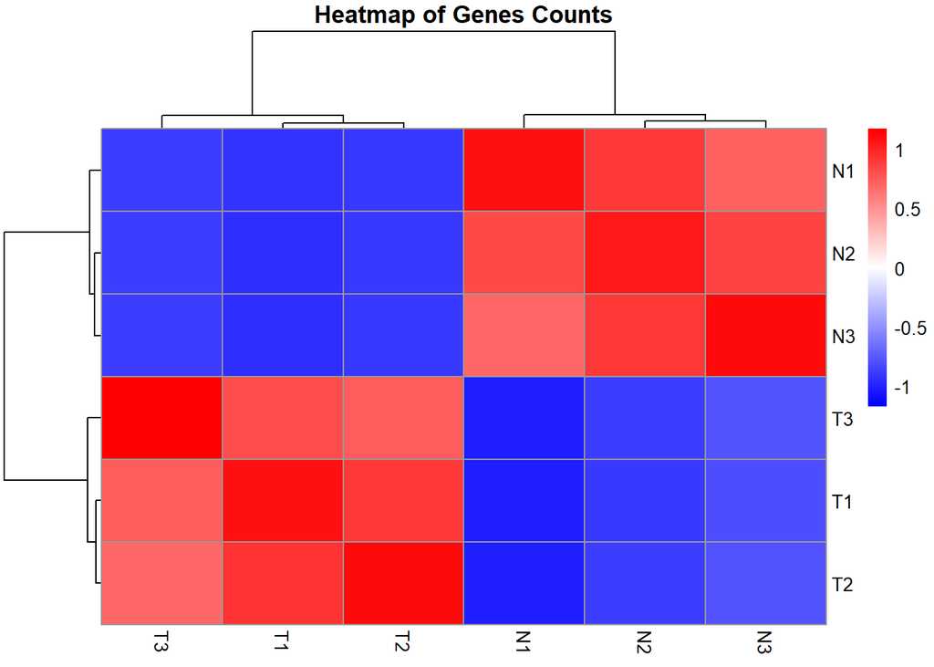

```r
heatmap_colors <- colorRampPalette(c("blue", "white", "red"))(100)
pheatmap(cor_gene,
        col = heatmap_colors,
        scale = "row",
        Rowv = FALSE,
        Colv = TRUE,
        main = "Heatmap of Genes Counts",
        margins = c(5, 10))
```

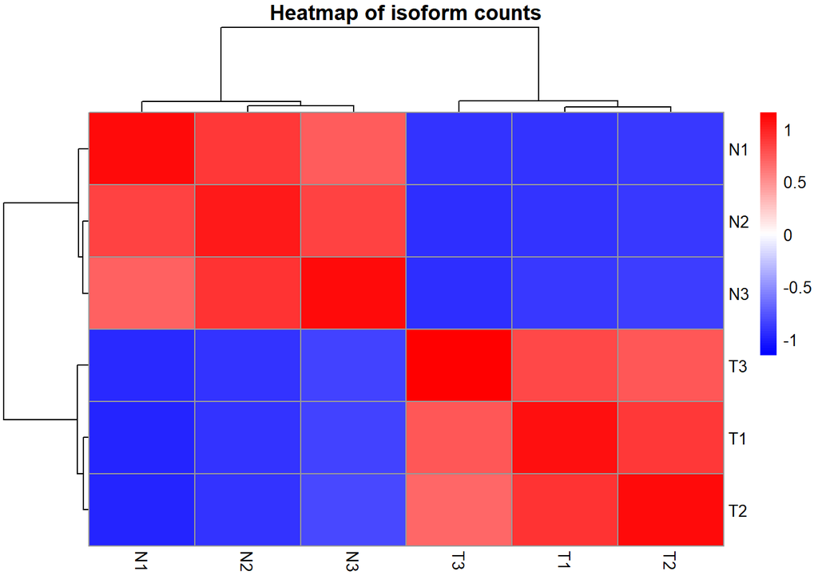

```r
pheatmap(cor_iso,
        col = heatmap_colors,
        scale = "row",
        Rowv = FALSE,
        Colv = TRUE,
        main = "Heatmap of isoform counts",
        margins = c(5, 10))
```

Both the two corrplots and the two heatmaps are very straightforward in showing that the treatment have an influence which creates clusters between treated and normal samples.